# IODS course project

```r
# multiple correspondence analysis
mca <- MCA(tea_time, graph = FALSE)

# summary of the model
summary(mca)
```

```
##
## Call:
## MCA(X = tea_time, graph = FALSE)
##
##
## Eigenvalues
##                        Dim.1   Dim.2   Dim.3   Dim.4   Dim.5   Dim.6   Dim.7
## Variance               0.279   0.261   0.219   0.189   0.177   0.156   0.144
## % of var.             15.238  14.232  11.964  10.333   9.667   8.519   7.841
## Cumulative % of var.  15.238  29.471  41.435  51.768  61.434  69.953  77.794
##                        Dim.8   Dim.9  Dim.10  Dim.11
## Variance               0.141   0.117   0.087   0.062
## % of var.              7.705   6.392   4.724   3.385
## Cumulative % of var.  85.500  91.891  96.615 100.000
##
## Individuals (the 10 first)
##                       Dim.1    ctr   cos2    Dim.2    ctr   cos2    Dim.3
## 1                  | -0.298  0.106  0.086 | -0.328  0.137  0.105 | -0.327
## 2                  | -0.237  0.067  0.036 | -0.136  0.024  0.012 | -0.695
## 3                  | -0.369  0.162  0.231 | -0.300  0.115  0.153 | -0.202
## 4                  | -0.530  0.335  0.460 | -0.318  0.129  0.166 |  0.211
## 5                  | -0.369  0.162  0.231 | -0.300  0.115  0.153 | -0.202
## 6                  | -0.369  0.162  0.231 | -0.300  0.115  0.153 | -0.202
## 7                  | -0.369  0.162  0.231 | -0.300  0.115  0.153 | -0.202
## 8                  | -0.237  0.067  0.036 | -0.136  0.024  0.012 | -0.695
## 9                  |  0.143  0.024  0.012 |  0.871  0.969  0.435 | -0.067
## 10                 |  0.476  0.271  0.140 |  0.687  0.604  0.291 | -0.650
##                       ctr   cos2
## 1                   0.163  0.104 |
## 2                   0.735  0.314 |
## 3                   0.062  0.069 |
## 4                   0.068  0.073 |
## 5                   0.062  0.069 |
## 6                   0.062  0.069 |
## 7                   0.062  0.069 |
## 8                   0.735  0.314 |
## 9                   0.007  0.003 |
## 10                  0.643  0.261 |
##
## Categories (the 10 first)
```

[output cut: 16 more lines]

```
## lemon                3.226 |   1.329  14.771   0.218   8.081 |
## milk                 2.422 |   0.013   0.003   0.000   0.116 |
## other                5.534 |  -2.524  14.526   0.197  -7.676 |
## tea bag             -6.941 |  -0.065   0.183   0.006  -1.287 |
## tea bag+unpackaged  11.956 |   0.019   0.009   0.000   0.226 |
## unpackaged          -6.482 |   0.257   0.602   0.009   1.640 |
##
## Categorical variables (eta2)
##                      Dim.1 Dim.2 Dim.3
## Tea                | 0.126 0.108 0.410 |
## How                | 0.076 0.190 0.394 |
## how                | 0.708 0.522 0.010 |
## sugar              | 0.065 0.001 0.336 |
## where              | 0.702 0.681 0.055 |
## lunch              | 0.000 0.064 0.111 |
```

```r
#
mca
```

```
## **Results of the Multiple Correspondence Analysis (MCA)**
## The analysis was performed on 300 individuals, described by 6 variables
## *The results are available in the following objects:
##
##    name              description
## 1  "$eig"            "eigenvalues"
## 2  "$var"            "results for the variables"
## 3  "$var$coord"      "coord. of the categories"
## 4  "$var$cos2"       "cos2 for the categories"
## 5  "$var$contrib"    "contributions of the categories"
## 6  "$var$v.test"     "v-test for the categories"
## 7  "$ind"            "results for the individuals"
## 8  "$ind$coord"      "coord. for the individuals"
## 9  "$ind$cos2"       "cos2 for the individuals"
## 10 "$ind$contrib"    "contributions of the individuals"
## 11 "$call"           "intermediate results"
## 12 "$call$marge.col" "weights of columns"
## 13 "$call$marge.li"  "weights of rows"
```

```r
# variance explained of each dimension
mca$eig
```

```
##        eigenvalue percentage of variance cumulative percentage of variance
## dim 1  0.27937118              15.238428                          15.23843
## dim 2  0.26092645              14.232352                          29.47078
## dim 3  0.21933575              11.963768                          41.43455
## dim 4  0.18943794              10.332978                          51.76753
## dim 5  0.17722310               9.666715                          61.43424
## dim 6  0.15617745               8.518770                          69.95301
## dim 7  0.14375727               7.841306                          77.79432
## dim 8  0.14126310               7.705260                          85.49958
## dim 9  0.11717818               6.391537                          91.89111
## dim 10 0.08660997               4.724180                          96.61529
## dim 11 0.06205294               3.384706                         100.00000
```

```r
#
mca$var$contrib
```

```
##                             Dim 1       Dim 2        Dim 3        Dim 4
## black                3.287594e+00  0.13878212 21.887888824  6.850933140
## Earl Grey            2.680131e+00  0.62646262  9.160346411  0.020492303
## green                1.547420e+00  6.11069011  0.098336420 18.196366111
## alone                1.221735e-02  2.84064831  0.627091507  7.634923867
## lemon                2.938354e+00  1.97876594 14.771053832  9.860510216
## milk                 1.420363e+00  0.98982417  0.002717798  1.190003769
## other                1.484609e-01  6.34717172 14.525710775 15.702219687
## tea bag              1.249854e+01  4.45932454  0.182502333  2.538219181
## tea bag+unpackaged   2.289406e+00 20.96801254  0.008924888  9.792937503
## unpackaged           2.743174e+01  7.89846283  0.601686755  2.542869346
## No.sugar             1.877265e+00  0.02312152 12.347410451  6.881816052
## sugar                2.006732e+00  0.02471610 13.198955999  7.356424056
## chain store          1.054364e+01  5.10306200  0.729631177  0.052452968
## chain store+tea shop 3.277838e+00 29.32477422  0.040321394  0.007720137
## tea shop             2.803984e+01  9.10196999  3.375125909  0.519945278
## lunch                3.959051e-04  3.46812696  7.204092184  9.260515317
## Not.lunch            6.804618e-05  0.59608432  1.238203344  1.591651070
##                             Dim 5
## black                 7.136402749
## Earl Grey             2.809090533
## green                 0.002798996
## alone                 9.631121839
## lemon                 1.470385143
## milk                 48.892955673
## other                 3.001603417
## tea bag               0.214439273
## tea bag+unpackaged    1.141826461
## unpackaged            0.518959332
## No.sugar              0.117922938
## sugar                 0.126055555
## chain store           0.071804648
## chain store+tea shop  0.781040940
## tea shop              0.558199638
## lunch                20.075001913
## Not.lunch             3.450390954
```

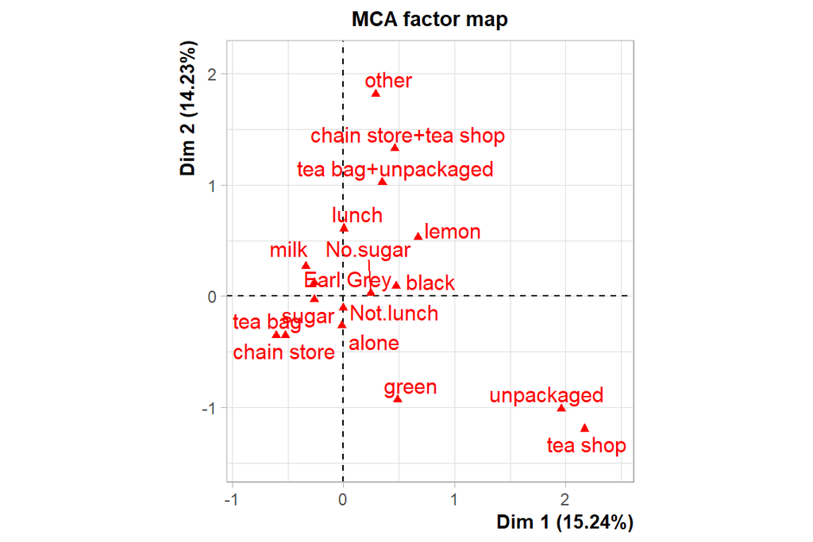

```r
# visualize MCA
plot(mca, invisible=c("ind"))
```

# Analysis of Longitudinal Data

## Chapter 8: Graphical Displays and summary measure approach

### The data=

The data set that will be used is from a nutrition study in three groups of rats (Crowder and Hand 1990). The weight of each rat was measured repeatedly 11 times every 7 weeks. The main objective is to determine if the different diets have effect on rats growth measured as weight.

The **rats** data set can be access using this [link](https://raw.githubusercontent.com/KimmoVehkalahti/MABS/master/Examples/data/rats.txt). The data set have 16 observations and 13 columns. It has a wide format wherein each column contains one repeated measurement for the same rat.

```r
RATS<-read.table("https://raw.githubusercontent.com/KimmoVehkalahti/MABS/master/Examples/data/rats.txt",
                 sep = "", header = TRUE)

dim(RATS); str(RATS); summary(RATS)
```

```
## [1] 16 13
```

```
## 'data.frame':    16 obs. of  13 variables:
##  $ ID   : int  1 2 3 4 5 6 7 8 9 10 ...
##  $ Group: int  1 1 1 1 1 1 1 1 2 2 ...
##  $ WD1  : int  240 225 245 260 255 260 275 245 410 405 ...
##  $ WD8  : int  250 230 250 255 260 265 275 255 415 420 ...
##  $ WD15 : int  255 230 250 255 255 270 260 260 425 430 ...
##  $ WD22 : int  260 232 255 265 270 275 270 268 428 440 ...
##  $ WD29 : int  262 240 262 265 270 275 273 270 438 448 ...
##  $ WD36 : int  258 240 265 268 273 277 274 265 443 460 ...
##  $ WD43 : int  266 243 267 270 274 278 276 265 442 458 ...
##  $ WD44 : int  266 244 267 272 273 278 271 267 446 464 ...
##  $ WD50 : int  265 238 264 274 276 284 282 273 456 475 ...
##  $ WD57 : int  272 247 268 273 278 279 281 274 468 484 ...
##  $ WD64 : int  278 245 269 275 280 281 284 278 478 496 ...
```

```
##        ID            Group           WD1             WD8             WD15
##  Min.   : 1.00   Min.   :1.00   Min.   :225.0   Min.   :230.0   Min.   :230.0
##  1st Qu.: 4.75   1st Qu.:1.00   1st Qu.:252.5   1st Qu.:255.0   1st Qu.:255.0
##  Median : 8.50   Median :1.50   Median :340.0   Median :345.0   Median :347.5
##  Mean   : 8.50   Mean   :1.75   Mean   :365.9   Mean   :369.1   Mean   :372.5
##  3rd Qu.:12.25   3rd Qu.:2.25   3rd Qu.:480.0   3rd Qu.:476.2   3rd Qu.:486.2
##  Max.   :16.00   Max.   :3.00   Max.   :555.0   Max.   :560.0   Max.   :565.0
##       WD22            WD29            WD36            WD43
##  Min.   :232.0   Min.   :240.0   Min.   :240.0   Min.   :243.0
##  1st Qu.:267.2   1st Qu.:268.8   1st Qu.:267.2   1st Qu.:269.2
##  Median :351.5   Median :356.5   Median :360.0   Median :360.0
##  Mean   :379.2   Mean   :383.9   Mean   :387.0   Mean   :386.0
##  3rd Qu.:492.5   3rd Qu.:497.8   3rd Qu.:504.2   3rd Qu.:501.0
##  Max.   :580.0   Max.   :590.0   Max.   :597.0   Max.   :595.0
##       WD44            WD50            WD57            WD64
##  Min.   :244.0   Min.   :238.0   Min.   :247.0   Min.   :245.0
##  1st Qu.:270.0   1st Qu.:273.8   1st Qu.:273.8   1st Qu.:278.0
##  Median :362.0   Median :370.0   Median :373.5   Median :378.0
##  Mean   :388.3   Mean   :394.6   Mean   :398.6   Mean   :404.1
##  3rd Qu.:510.5   3rd Qu.:516.0   3rd Qu.:524.5   3rd Qu.:530.8
##  Max.   :595.0   Max.   :612.0   Max.   :618.0   Max.   :628.0
```

Notice after loading the data set, R did not recognized the first two columns (**ID** and **Group**) as categorical variables. It has to be manually changed into categorical variables (**as.factor**). Furthermore, the data has to be converted into a long format by collapsing the repeated measurements into one column **weight**.

```r
library(dplyr)
library(tidyr)

lRATS <- RATS %>%
  mutate(
    fID = as.factor(ID),                        # create a new column $fID, which contains categorical variable
    fGroup = as.factor(Group)                   # create a new column $fGroup which contains categorical variable
  ) %>%
  dplyr::select(c(-ID, -Group)) %>%                          # Remove the columns ID and Group
  gather(key = time, value = weight, -fID, -fGroup) %>%      # Reformat the data set from wide to long
  dplyr::mutate(week = as.integer(substr(time, 3,4)))        # create a new column $week which contains the numerical part of the column $time

#' lRATS <- long format of RATS data set
str(lRATS)
```

```
## 'data.frame':    176 obs. of  5 variables:
##  $ fID   : Factor w/ 16 levels "1","2","3","4",..: 1 2 3 4 5 6 7 8 9 10 ...
##  $ fGroup: Factor w/ 3 levels "1","2","3": 1 1 1 1 1 1 1 1 2 2 ...
##  $ time  : chr  "WD1" "WD1" "WD1" "WD1" ...
##  $ weight: int  240 225 245 260 255 260 275 245 410 405 ...
##  $ week  : int  1 1 1 1 1 1 1 1 1 1 ...
```

### Graphical overview

We can further explore the data by creating plots to discover patterns. The first plot shows the weight of each rats overtime. The plot shows that there is uneven number of rats on each diet treatment. Furthermore, the initial weight of the rats vary across treatment. Overall, all the rats gained weight regardless of what type of diet they received.

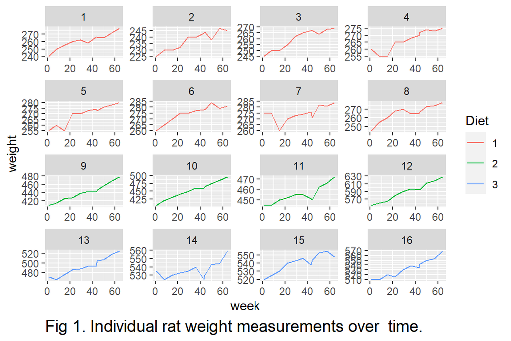

```r
library(ggplot2)

p1 <- ggplot(lRATS, aes(x = week, y = weight)) + geom_line(aes(color = fGroup))
p1 <- p1 + facet_wrap( ~ fID, scale = 'free')
p1 <- p1 + labs(color = 'Diet', caption = 'Fig 1. Individual rat weight measurements over  time.')
p1 <- p1 + theme(plot.caption = element_text(hjust = 0, size = 14))

p1
```

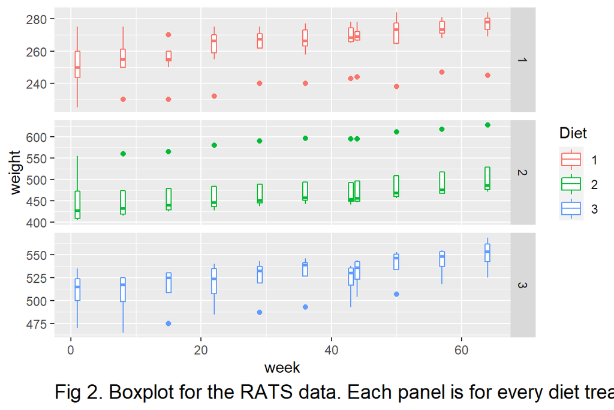

```r
#' Boxplot
p2 <- ggplot(lRATS, aes(x = week, y = weight, group = week)) + geom_boxplot(aes(color = fGroup))
p2 <- p2 + labs(color = 'Diet', caption = 'Fig 2. Boxplot for the RATS data. Each panel is for every diet treatment')
p2 <- p2 + facet_grid( fGroup ~ ., scale = 'free')
p2 <- p2 + theme(plot.caption = element_text(hjust = 0, size = 14))
p2
```

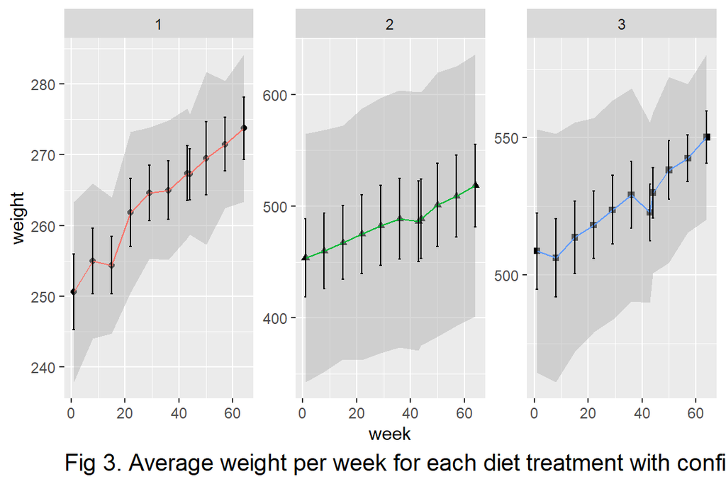

```r
#' Summary
library(Rmisc)
aveRats <- summarySE(data = lRATS, measurevar = 'weight', groupvars = c('week', 'fGroup'))

p3 <- ggplot(aveRats, aes(x = week, y = weight)) + geom_point(aes(shape = fGroup))
p3 <- p3 + geom_ribbon(aes(ymin = weight - ci, ymax = weight + ci), fill = "grey70", alpha = 0.5) + geom_line(aes(color = fGroup))
p3 <- p3 + geom_errorbar(aes(ymin = weight - se, ymax = weight + se))
p3 <- p3 + theme(legend.position = 'none',
                 plot.caption = element_text(hjust = 0, size = 14)) +
  labs(caption = 'Fig 3. Average weight per week for each diet treatment with confidence interval. error bars = Standard Error')
p3 <- p3 + facet_wrap(fGroup ~ ., scale = 'free')
p3
```

**Fig 4** shows boxplots of rat’s average weight from week 1 - 64 for each treatment.Rats that receives diet 1 is smaller compared to the rats which received the other treatment. Furthermore, rat weight in diet 2 are skewed towards smaller rats.

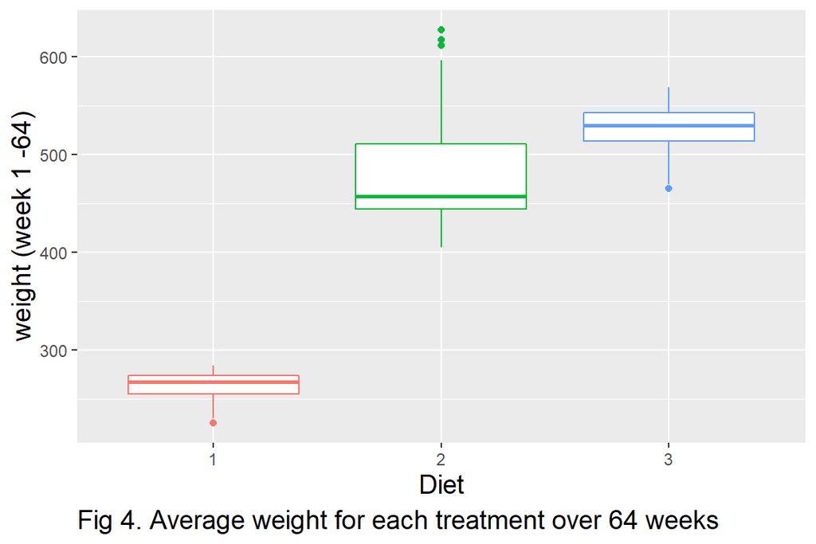

```r
#' average weight over week 0 - 64
p4 <- ggplot(lRATS, aes(x = fGroup, y = weight, group = fGroup)) + geom_boxplot(aes(color = fGroup))
p4 <- p4 + labs(x = 'Diet', y = 'weight (week 1 -64)', caption = 'Fig 4. Average weight for each treatment over 64 weeks')
p4 <- p4 + theme(axis.title = element_text(size = 14),
                 legend.position = 'none', plot.caption = element_text(hjust = 0, size = 14))
p4
```

### Fitting a model

Analysis of variance suggests that the weight of the rats from each diet are significantly different. Post hoc test suggest the pairwise difference among the diet tretment are all significant as well.

```r
library(pander)
#' anova
fit1 <- aov(weight ~ fGroup, data = lRATS)
pander(summary(fit1))
```

Analysis of Variance Model

|  | Df | Sum Sq | Mean Sq | F value | Pr(>F) |
| --- | --- | --- | --- | --- | --- |
| **fGroup** | 2 | 2604050 | 1302025 | 998.2 | 9.965e-96 |
| **Residuals** | 173 | 225662 | 1304 | NA | NA |

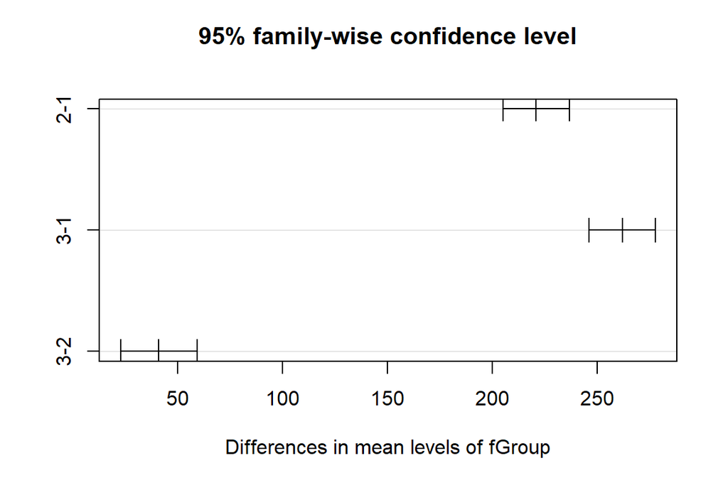

```r
plot(TukeyHSD(fit1))
```

```r
#' linear model
fit2 <- lm(weight ~ fGroup, data = lRATS)
pander(summary(fit2))
```

|  | Estimate | Std. Error | t value | Pr(>\|t\|) |
| --- | --- | --- | --- | --- |
| **(Intercept)** | 263.7 | 3.85 | 68.5 | 2.816e-127 |
| **fGroup2** | 221 | 6.668 | 33.14 | 7.756e-77 |
| **fGroup3** | 262.1 | 6.668 | 39.3 | 3.762e-88 |

Fitting linear model: weight ~ fGroup

| Observations | Residual Std. Error | $R^2$ | Adjusted $R^2$ |
| --- | --- | --- | --- |
| 176 | 36.12 | 0.9203 | 0.9193 |

## Chapter 9: Linear mixed effects models

### The data

The **BPRS** data will be used on this exercise (Davis 2002). The data set contains information about 40 males randomly assigned to one of the two treatments. Initial psychiatric rating scale (BPRS) was measured before the treatment (Week 0), and measured thereafter at weekly interval for 8 weeks. The scale is used to evaluate if a person has schizophrenia.

The scatterplots clearly shows the repeated measure nature of the BPRS scores for both treatment.

```r
#' upload data
BPRS<-read.table("https://raw.githubusercontent.com/KimmoVehkalahti/MABS/master/Examples/data/BPRS.txt",
                 sep = "", header = TRUE)

#' explore data
dim(BPRS); str(BPRS); summary(BPRS)
```

```
## [1] 40 11
```

```
## 'data.frame':    40 obs. of  11 variables:
##  $ treatment: int  1 1 1 1 1 1 1 1 1 1 ...
##  $ subject  : int  1 2 3 4 5 6 7 8 9 10 ...
##  $ week0    : int  42 58 54 55 72 48 71 30 41 57 ...
##  $ week1    : int  36 68 55 77 75 43 61 36 43 51 ...
##  $ week2    : int  36 61 41 49 72 41 47 38 39 51 ...
##  $ week3    : int  43 55 38 54 65 38 30 38 35 55 ...
##  $ week4    : int  41 43 43 56 50 36 27 31 28 53 ...
##  $ week5    : int  40 34 28 50 39 29 40 26 22 43 ...
##  $ week6    : int  38 28 29 47 32 33 30 26 20 43 ...
##  $ week7    : int  47 28 25 42 38 27 31 25 23 39 ...
##  $ week8    : int  51 28 24 46 32 25 31 24 21 32 ...
```

```
##    treatment      subject          week0           week1           week2
##  Min.   :1.0   Min.   : 1.00   Min.   :24.00   Min.   :23.00   Min.   :26.0
##  1st Qu.:1.0   1st Qu.: 5.75   1st Qu.:38.00   1st Qu.:35.00   1st Qu.:32.0
##  Median :1.5   Median :10.50   Median :46.00   Median :41.00   Median :38.0
##  Mean   :1.5   Mean   :10.50   Mean   :48.00   Mean   :46.33   Mean   :41.7
##  3rd Qu.:2.0   3rd Qu.:15.25   3rd Qu.:58.25   3rd Qu.:54.25   3rd Qu.:49.0
##  Max.   :2.0   Max.   :20.00   Max.   :78.00   Max.   :95.00   Max.   :75.0
##      week3           week4           week5           week6           week7
##  Min.   :24.00   Min.   :20.00   Min.   :20.00   Min.   :19.00   Min.   :18.0
##  1st Qu.:29.75   1st Qu.:28.00   1st Qu.:26.00   1st Qu.:22.75   1st Qu.:23.0
##  Median :36.50   Median :34.50   Median :30.50   Median :28.50   Median :30.0
##  Mean   :39.15   Mean   :36.35   Mean   :32.55   Mean   :31.23   Mean   :32.2
##  3rd Qu.:44.50   3rd Qu.:43.00   3rd Qu.:38.00   3rd Qu.:37.00   3rd Qu.:38.0
##  Max.   :76.00   Max.   :66.00   Max.   :64.00   Max.   :64.00   Max.   :62.0
##      week8
##  Min.   :20.00
##  1st Qu.:22.75
##  Median :28.00
##  Mean   :31.43
##  3rd Qu.:35.25
##  Max.   :75.00
```

```r
head(BPRS)
```

```
##   treatment subject week0 week1 week2 week3 week4 week5 week6 week7 week8
## 1         1       1    42    36    36    43    41    40    38    47    51
## 2         1       2    58    68    61    55    43    34    28    28    28
## 3         1       3    54    55    41    38    43    28    29    25    24
## 4         1       4    55    77    49    54    56    50    47    42    46
## 5         1       5    72    75    72    65    50    39    32    38    32
## 6         1       6    48    43    41    38    36    29    33    27    25
```

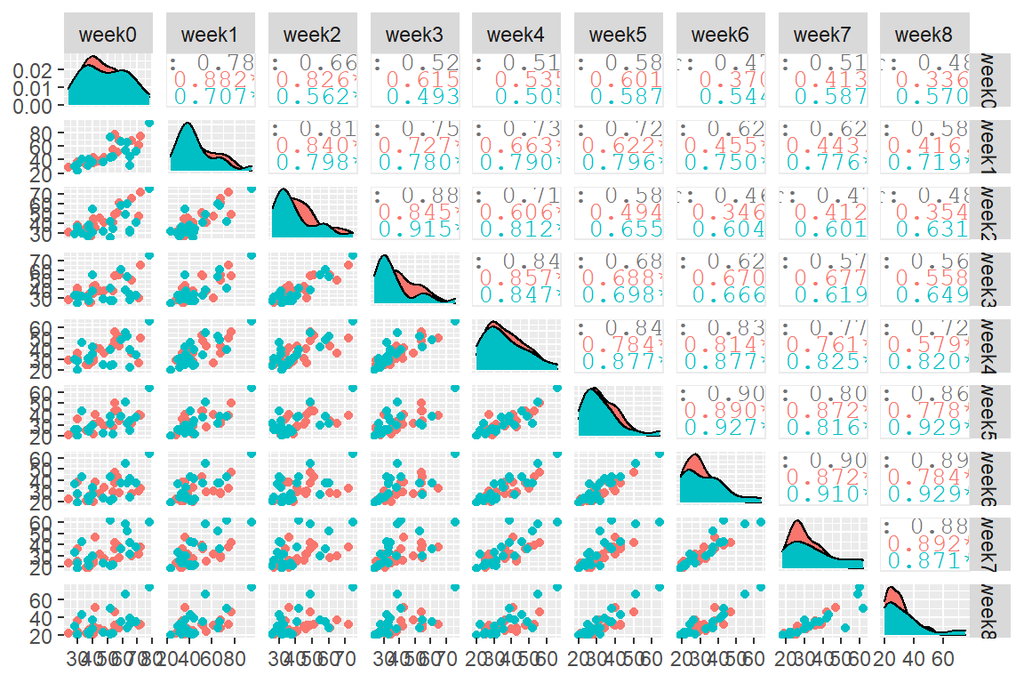

```r
#' scatterplot
#BPRS$subject<-as.factor(BPRS$subject)
library(GGally)
ggpairs(BPRS[,3:11], ggplot2::aes(color = as.factor(BPRS$treatment)))
```

### Converting wide to long data

The data set is in wide format and needs to change to long format before further analyses.

```r
library(dplyr)
library(tidyr)
lBPRS <- BPRS %>%
  mutate(
    ftreatment = as.factor(treatment),
    fsubject = as.factor(subject)
  ) %>%
  dplyr::select(c(-treatment, -subject)) %>%
  gather(key = weeks, value = bprs, -ftreatment, -fsubject) %>%
  dplyr::mutate(week = as.integer(substr(weeks, 5,5)))

#' explore data
head(lBPRS, 5)
```

```
##   ftreatment fsubject weeks bprs week
## 1          1        1 week0   42    0
## 2          1        2 week0   58    0
## 3          1        3 week0   54    0
## 4          1        4 week0   55    0
## 5          1        5 week0   72    0
```

```r
str(lBPRS)
```

```
## 'data.frame':    360 obs. of  5 variables:
##  $ ftreatment: Factor w/ 2 levels "1","2": 1 1 1 1 1 1 1 1 1 1 ...
##  $ fsubject  : Factor w/ 20 levels "1","2","3","4",..: 1 2 3 4 5 6 7 8 9 10 ...
##  $ weeks     : chr  "week0" "week0" "week0" "week0" ...
##  $ bprs      : int  42 58 54 55 72 48 71 30 41 57 ...
##  $ week      : int  0 0 0 0 0 0 0 0 0 0 ...
```

```r
lBPRS$ID <- rep(1:40, 9) %>% as.factor()
```

### Graphical overview

Plotting the bprs scores over time for each subject shows decreasing trend in most cases for both treatment.

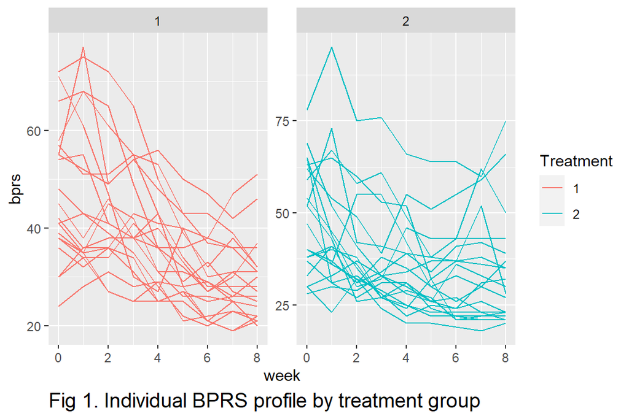

```r
#' Graphical overview
p1 <- ggplot(lBPRS, aes(x = week, y = bprs, group = ID)) + geom_line(aes(color = ftreatment))
p1 <- p1 + labs(color = 'Treatment', caption = 'Fig 1. Individual BPRS profile by treatment group')
p1 <- p1 + theme(plot.caption = element_text(hjust = 0, size = 14)) +
  facet_wrap(~ ftreatment, scale = 'free')
p1
```

### Linear regression model

Different models were tested to predict bprs scores. By comparing the AIC scores of the three models, the best model was found to be with random intercept and random slope without interaction between the fixed variables. Furthermore, the treatment did not result to significant difference in bprs scores.

```r
#'linear model
library(lme4)
library(sjmisc)
library(sjPlot)
library(pander)
fit1 <- lm(bprs ~ week + ftreatment, data = lBPRS)
pander(summary(fit1))
```

|  | Estimate | Std. Error | t value | Pr(>\|t\|) |
| --- | --- | --- | --- | --- |
| **(Intercept)** | 46.45 | 1.367 | 33.98 | 6.256e-114 |
| **week** | -2.27 | 0.2524 | -8.995 | 1.413e-17 |
| **ftreatment2** | 0.5722 | 1.303 | 0.439 | 0.6609 |

Fitting linear model: bprs ~ week + ftreatment

| Observations | Residual Std. Error | $R^2$ | Adjusted $R^2$ |
| --- | --- | --- | --- |
| 360 | 12.37 | 0.1851 | 0.1806 |

```r
#' subject as random effect
fit2 <- lmer(bprs ~ week + ftreatment + (1 | ID), data = lBPRS, REML = FALSE)


fit3 <- lmer(bprs ~ week + ftreatment + (week | ID), data = lBPRS, REML = FALSE)


fit4 <- lmer(bprs ~ week * ftreatment + (week | ID), data = lBPRS, REML = FALSE)
tab_model(fit2, fit3, fit4,
          dv.labels = c('Random Intercept', 'Random Intercept & Slope', 'Randrom Intercept & Slope + Interaction'))
```

|  | Random Intercept |  |  | Random Intercept & Slope |  |  | Randrom Intercept & Slope + Interaction |  |  |
| --- | --- | --- | --- | --- | --- | --- | --- | --- | --- |
| Predictors | Estimates | CI | p | Estimates | CI | p | Estimates | CI | p |
| (Intercept) | 46.45 | 41.84 – 51.06 | **<0.001** | 45.98 | 40.80 – 51.17 | **<0.001** | 47.89 | 42.04 – 53.73 | **<0.001** |
| week | -2.27 | -2.57 – -1.98 | **<0.001** | -2.27 | -2.80 – -1.74 | **<0.001** | -2.63 | -3.36 – -1.89 | **<0.001** |
| ftreatment [2] | 0.57 | -5.73 – 6.88 | 0.859 | 1.51 | -4.64 – 7.67 | 0.630 | -2.29 | -10.56 – 5.98 | 0.587 |
| week * ftreatment [2] |  |  |  |  |  |  | 0.72 | -0.32 – 1.76 | 0.177 |
| Random Effects |  |  |  |  |  |  |  |  |  |
| σ<sup>2</sup> | 54.23 |  |  | 36.75 |  |  | 36.75 |  |  |
| τ<sub>00</sub> | 97.39 <sub>ID</sub> |  |  | 167.83 <sub>ID</sub> |  |  | 164.20 <sub>ID</sub> |  |  |
| τ<sub>11</sub> |  |  |  | 2.33 <sub>ID.week</sub> |  |  | 2.20 <sub>ID.week</sub> |  |  |
| ρ<sub>01</sub> |  |  |  | -0.67 <sub>ID</sub> |  |  | -0.66 <sub>ID</sub> |  |  |
| ICC | 0.64 |  |  | 0.76 |  |  | 0.76 |  |  |
| N | 40 <sub>ID</sub> |  |  | 40 <sub>ID</sub> |  |  | 40 <sub>ID</sub> |  |  |
| Observations | 360 |  |  | 360 |  |  | 360 |  |  |
| Marginal R<sup>2</sup> / Conditional R<sup>2</sup> | 0.186 / 0.709 |  |  | 0.187 / 0.803 |  |  | 0.190 / 0.803 |  |  |

```r
pander(anova(fit2, fit3, fit4))
```

Data: lBPRS

|  | npar | AIC | BIC | logLik | deviance | Chisq | Df | Pr(>Chisq) |
| --- | --- | --- | --- | --- | --- | --- | --- | --- |
| **fit2** | 5 | 2583 | 2602 | -1286 | 2573 | NA | NA | NA |
| **fit3** | 7 | 2523 | 2550 | -1255 | 2509 | 63.66 | 2 | 1.499e-14 |
| **fit4** | 8 | 2523 | 2555 | -1254 | 2507 | 1.78 | 1 | 0.1821 |

## Predict

BPRS scores can be predicted using the selected model. The results from **t.test** between the predicted value to the actual bprs scores suggest the model can fairly predict BPRS scores (**Fig 2a and 2b**).

```r
lBPRS$pred <- predict(fit3, type = 'response') %>% as.integer()
str(lBPRS)
```

```
## 'data.frame':    360 obs. of  7 variables:
##  $ ftreatment: Factor w/ 2 levels "1","2": 1 1 1 1 1 1 1 1 1 1 ...
##  $ fsubject  : Factor w/ 20 levels "1","2","3","4",..: 1 2 3 4 5 6 7 8 9 10 ...
##  $ weeks     : chr  "week0" "week0" "week0" "week0" ...
##  $ bprs      : int  42 58 54 55 72 48 71 30 41 57 ...
##  $ week      : int  0 0 0 0 0 0 0 0 0 0 ...
##  $ ID        : Factor w/ 40 levels "1","2","3","4",..: 1 2 3 4 5 6 7 8 9 10 ...
##  $ pred      : int  39 63 52 62 74 46 57 37 42 57 ...
```

```r
t.test(lBPRS$pred, lBPRS$bprs)
```

```
##
##  Welch Two Sample t-test
##
## data:  lBPRS$pred and lBPRS$bprs
## t = -0.54049, df = 705.26, p-value = 0.589
## alternative hypothesis: true difference in means is not equal to 0
## 95 percent confidence interval:
##  -2.393452  1.360118
## sample estimates:
## mean of x mean of y
##  37.14167  37.65833
```

```r
llBPRS <- lBPRS %>% gather(key = type, value = bprs, -ftreatment, -fsubject, -weeks, -week, -ID)

llBPRS <- llBPRS %>% mutate(
  type = as.factor(type),
  week = as.factor(week),
  ID = as.factor(ID)
)
str(llBPRS)
```

```
## 'data.frame':    720 obs. of  7 variables:
##  $ ftreatment: Factor w/ 2 levels "1","2": 1 1 1 1 1 1 1 1 1 1 ...
##  $ fsubject  : Factor w/ 20 levels "1","2","3","4",..: 1 2 3 4 5 6 7 8 9 10 ...
##  $ weeks     : chr  "week0" "week0" "week0" "week0" ...
##  $ week      : Factor w/ 9 levels "0","1","2","3",..: 1 1 1 1 1 1 1 1 1 1 ...
##  $ ID        : Factor w/ 40 levels "1","2","3","4",..: 1 2 3 4 5 6 7 8 9 10 ...
##  $ type      : Factor w/ 2 levels "bprs","pred": 1 1 1 1 1 1 1 1 1 1 ...
##  $ bprs      : int  42 58 54 55 72 48 71 30 41 57 ...
```

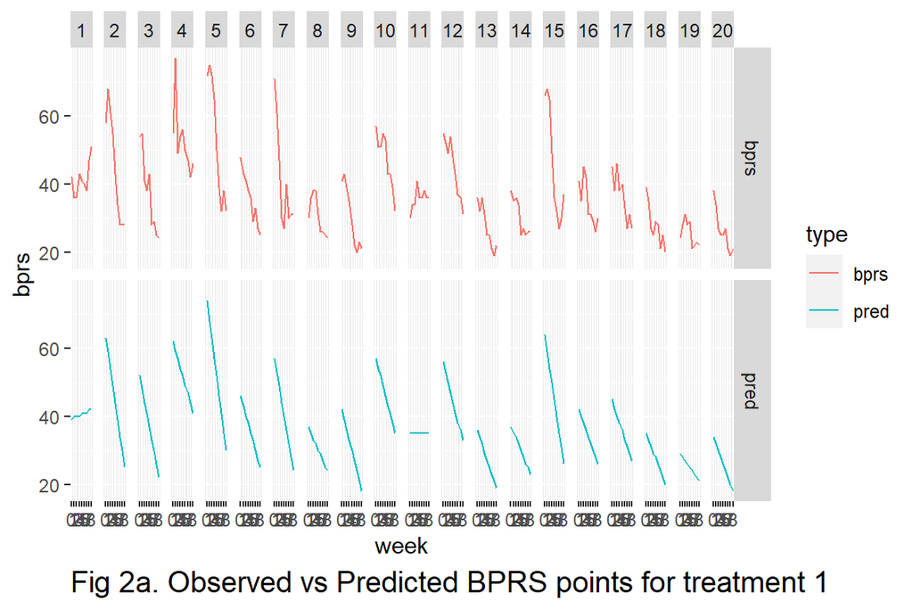

```r
p2a <- ggplot(subset(llBPRS, ftreatment == '1'), aes(x = week, y = bprs, group = ID)) + geom_line(aes(color = type))
p2a <- p2a + labs(caption = 'Fig 2a. Observed vs Predicted BPRS points for treatment 1') +
  facet_grid( type ~ fsubject) +
  theme(plot.caption = element_text(hjust = 0, size = 14))
p2a
```

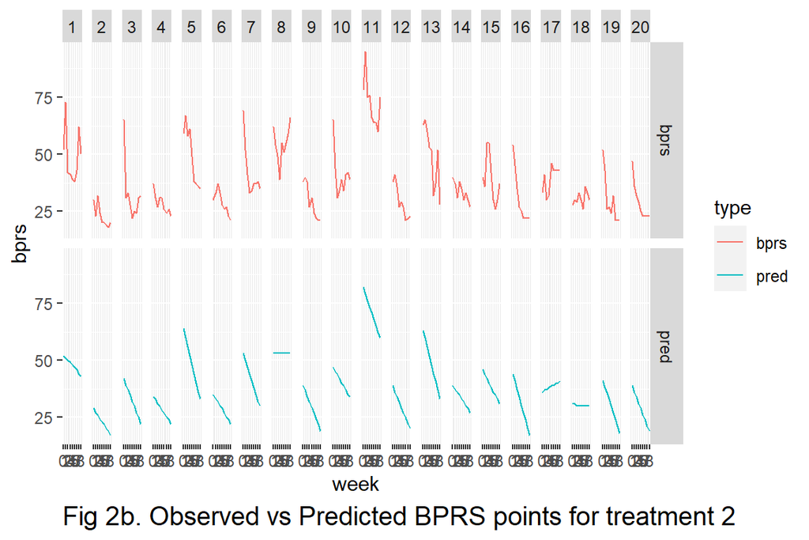

```r
p2b <- ggplot(subset(llBPRS, ftreatment == '2'), aes(x = week, y = bprs, group = ID)) + geom_line(aes(color = type))
p2b <- p2b + labs(caption = 'Fig 2b. Observed vs Predicted BPRS points for treatment 2') +
  facet_grid( type ~ fsubject) +
  theme(plot.caption = element_text(hjust = 0, size = 14))
p2b
```